# Permutation Test Distribution examination

Naveed Merchant

October 5, 2018

I fixed computation issues earlier so underflow should no longer be a problem.

We can run through and see how our “importance sampling test does”

```r
#Run this as a loop and examine shape of density of BF's
LBF<-c()
set.seed(1000)
for(D in 1:100)
{
  dataset<- rnorm(500)
  X1 <- dataset[1:(length(dataset)*.3)]
  X2 <- dataset[-(1:(length(dataset)*.3))]
  datasetperm <- sample(dataset)
  X1perm <- datasetperm[1:(length(dataset)*.3)]
  X2perm <- datasetperm[-(1:(length(dataset)*.3))]

  cauchsamp<- rcauchy(100)

  poscauchsamp <- cauchsamp[cauchsamp > 0]

#We draw from truncated cauchy, this is because we want our bandwidth to be always positive.

B <- (quantile(X2,probs = .75) - quantile(X2,probs = .25))/1.35

#Used in prior for bandwidth

importancepart <- ((2*B*(1/poscauchsamp^2)*(exp(-(B^2)/(poscauchsamp)^2)) / sqrt(pi))) / (2*dcauchy(poscauchsamp))

#Computes prior after adjusting for drawing from cauchy

#The next few lines evaluate the likelihood of the model under the gaussian kernel.


k <- length(X1)
n <- length(X2)
sum <- 0
prod <- 0
sum2 <- 0
prod2 <- 0

prodlist1<-c()
prodlist2<-c()

for(z in 1:length(poscauchsamp))
{
  prod <- 0
  for(j in 1:n)
  {
    sum <- 0
    for(i in 1:k)
    {
      sum <- sum + exp(-.5*((X2[j]-X1[i])/poscauchsamp[z])^2)
    }
    prod <- prod + log(sum) + log((1/sqrt(2*pi))) + log((k*poscauchsamp[z])^(-1))
  }
  prodlist1[z] <- prod + log(importancepart[z])
}
for(z in 1:length(poscauchsamp))
{
  prod <- 0
  for(j in 1:n)
  {
    sum <- 0
    for(i in 1:k)
    {
      sum <- sum + exp(-.5*((X2perm[j]-X1perm[i])/poscauchsamp[z])^2)
    }
    prod <- prod + log(sum) + log((1/sqrt(2*pi))) + log((k*poscauchsamp[z])^(-1))
  }
  prodlist2[z] <- prod + log(importancepart[z])
}
BF1 <- sum(exp(prodlist1-max(prodlist2))) / sum(exp(prodlist2-max(prodlist2)))
logBF1 <- log(BF1)
LBF[D]<-logBF1
}

summary(LBF)
```

```
##      Min.   1st Qu.    Median      Mean   3rd Qu.      Max.
## -12.46487  -3.62010   0.04324   0.21853   3.10512  18.96913
```

```r
sd(LBF)
```

```
## [1] 5.951309
```

```r
median(LBF)
```

```
## [1] 0.04323837
```

```r
mean(LBF)
```

```
## [1] 0.2185267
```

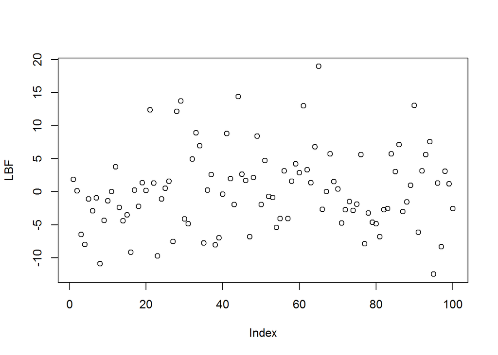

```r
plot(LBF)
```

```r
#This calculation is very time expensive!

#One of the permutations is favored quite harshly!
```

This is the plot of the log(bayes factor) not the bayes factor, so these things are very small and very large!

```r
logintegnormguess <- (-(n/2)) * log(2*pi) - .5*log(n+1) + (-.5*sum(X2^2)) + (-.5*(sum(X2)^2)/(n+1))
BF2 <- logintegnormguess - log(sum(exp(prodlist1)))
BF2
```

```
## [1] 1.454854
```

```r
logintegnormguess - log(sum(exp(prodlist2)))
```

```
## [1] -1.08977
```

Normal distribution is favored (admittedly not by much).

It’s also favored by 1 kernel and less favored by permuted kernel.

```r
#Choose bandwidth that satisfies some important quality
#I.e. maximum likelihood, SURE, etc.
#https://d-nb.info/104355470X/34

#Do this with current dataset.

#Permute dataset and redo this procedure.

#If datasets are from common distribution this should be OK?

#We can optimize the likelihood
#Split X into 3 parts (X1,X2,X3)
X1 <- dataset[1:(length(dataset)*.3)]
X2 <- dataset[(length(dataset)*.3 + 1):(length(dataset)*.6)]
X3 <- dataset[(length(dataset)*.6 + 1):(length(dataset))]

GaussKernLik <- function(h,X1,X2)
{
  prod <- 0
  k <- length(X1)
  n <- length(X2)
  for(j in 1:n)
  {
    sum <- 0
    for(i in 1:k)
    {
      sum <- sum + exp(-.5*((X2[j]-X1[i])/h)^2)
    }
    prod <- prod + log(sum) + log((1/sqrt(2*pi))) + log((k*h)^(-1))
  }
  return(prod)
}
h<-1
Optimumbandwidthreg <- optimize(GaussKernLik, X1 = X1, X2 = X2, lower = .00001, upper = 5, maximum = TRUE, tol = .001)

#Optimize runs pretty fast.
X1perm <- datasetperm[1:(length(dataset)*.3)]
X2perm <- datasetperm[(length(dataset)*.3 + 1):(length(dataset)*.6)]
X3perm <- datasetperm[(length(dataset)*.6 + 1):(length(dataset))]


Optimumbandwidthperm <- optimize(GaussKernLik, X1 = X1perm, X2 = X2perm, lower = .00001, upper = 5, maximum = TRUE, tol = .001)

#We have an estimate for our bandwidth, we proceed with the test.

BFPriorFree <- GaussKernLik(Optimumbandwidthreg$maximum,X1 = X1, X2 = X3) - GaussKernLik(Optimumbandwidthperm$maximum,X1 = X1perm, X2 = X3perm)

BFPriorFree
```

```
## [1] -9.858094
```

```r
#This is very volatile

#We want to go ahead and try the idea in the paper that tries to test to see if things come from common distributions too.
```

```r
#Uh actually what does it mean if things share a common distribution again?

#Draw from a normal and exponential perhaps?
set.seed(300)
dataset1 <- rnorm(1000,mean = 10, sd =1)

dataset2 <- rexp(1000, rate = 1/10)

x <- c(dataset1, dataset2)

dataset <- sample(x)
datasetperm <- sample(dataset)

X1 <- dataset[1:(length(dataset)*.3)]
X2 <- dataset[(length(dataset)*.3 + 1):(length(dataset)*.6)]
X3 <- dataset[(length(dataset)*.6 + 1):(length(dataset))]

GaussKernLik <- function(h,X1,X2)
{
  prod <- 0
  k <- length(X1)
  n <- length(X2)
  for(j in 1:n)
  {
    sum <- 0
    for(i in 1:k)
    {
      sum <- sum + exp(-.5*((X2[j]-X1[i])/h)^2)
    }
    prod <- prod + log(sum) + log((1/sqrt(2*pi))) + log((k*h)^(-1))
  }
  return(prod)
}
h<-1
Optimumbandwidthreg <- optimize(GaussKernLik, X1 = X1, X2 = X2, lower = .00001, upper = 5, maximum = TRUE, tol = .001)

#Optimize runs pretty fast.
X1perm <- datasetperm[1:(length(dataset)*.3)]
X2perm <- datasetperm[(length(dataset)*.3 + 1):(length(dataset)*.6)]
X3perm <- datasetperm[(length(dataset)*.6 + 1):(length(dataset))]


Optimumbandwidthperm <- optimize(GaussKernLik, X1 = X1perm, X2 = X2perm, lower = .00001, upper = 5, maximum = TRUE, tol = .001)

BFPriorFree <- GaussKernLik(Optimumbandwidthreg$maximum,X1 = X1, X2 = X3perm) - GaussKernLik(Optimumbandwidthperm$maximum,X1 = X1perm, X2 = X3)

BFPriorFree
```

```
## [1] -128.3634
```

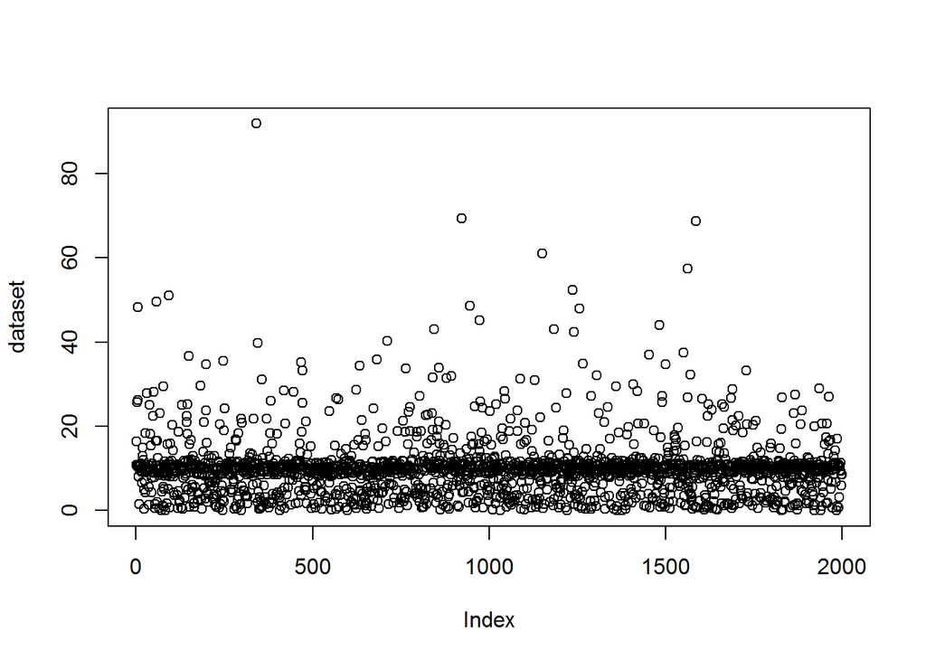

```r
plot(dataset)
```

Well one of the kernels is clearly harshly favored (this is far more true then before as well). I want to see what happens if we pass which distribution the data was drawn from and proceed.

```r
set.seed(300)
dataset1 <- rnorm(1000,mean = 10, sd =1)

dataset2 <- rexp(1000)


dataset <- dataset1
datasetperm <- dataset2

X1 <- dataset[1:(length(dataset)*.3)]
X2 <- dataset[(length(dataset)*.3 + 1):(length(dataset)*.6)]
X3 <- dataset[(length(dataset)*.6 + 1):(length(dataset))]



h<-1
Optimumbandwidthreg <- optimize(GaussKernLik, X1 = X1, X2 = X2, lower = .00001, upper = 5, maximum = TRUE, tol = .001)

#Optimize runs pretty fast but seems to be slow if datasets are large (understandable as f is v. tiresome to compute.
X1perm <- datasetperm[1:(length(dataset)*.3)]
X2perm <- datasetperm[(length(dataset)*.3 + 1):(length(dataset)*.6)]
X3perm <- datasetperm[(length(dataset)*.6 + 1):(length(dataset))]


Optimumbandwidthperm <- optimize(GaussKernLik, X1 = X1perm, X2 = X2perm, lower = .00001, upper = 5, maximum = TRUE, tol = .001)

BFPriorFree <- GaussKernLik(Optimumbandwidthreg$maximum,X1 = X1, X2 = X3perm) - GaussKernLik(Optimumbandwidthperm$maximum,X1 = X1perm, X2 = X3)

BFPriorFree
```

```
## [1] -59549.97
```

This is very small…

So I’m not sure what to think, the bayes factor has always been negative but it definetly feels far more negative when the distributions are off. Perhaps an examination of how things are when both datasets are clearly drawn from a certain distribution is in order.

```r
set.seed(500)
dataset1 <- rnorm(500)
dataset2 <- rnorm(500)

n <- length(dataset1)
m <- length(dataset2)
Jk1 <- 0
Jk2 <- 0
Jk3 <- 0
b <- 1
for(j in 1:n)
{
  for(l in 1:n)
  {
    if(j != l)
      Jk1 = Jk1 + exp(-.5 *((dataset1[j] - dataset1[l])/(sqrt(2)*b))^2)
  }
}


for(j in 1:m)
{
  for(l in 1:m)
  {
    if(j != l)
      Jk2 = Jk2 + exp(-.5 *((dataset2[j] - dataset2[l])/(sqrt(2)*b))^2)
  }
}

for(j in 1:n)
{
  for(l in 1:m)
  {
      Jk3 = Jk3 + exp(-.5 *((dataset1[j] - dataset2[l])/(sqrt(2)*b))^2)
  }
}

Jk = Jk1 / (n * (n-1)) + Jk2 / (m * (m-1)) + Jk3 * 2 / (n*m)

Jk / sqrt(1)
```

```
## [1] 2.816554
```

```r
#Well its not 0, lets see what its variance is supposed to be

#By spectral analysis: Var(J1) = var(J1),

#This isn't working out as planned...
```

Thoughts on how to compute variance estimate in just a 1 sample setting? The paper seems to assume that the variances are similar under the null, and we can estimate variances under each of them and examine appropriately.

It doesn’t appear easy to do this in a simpler case.

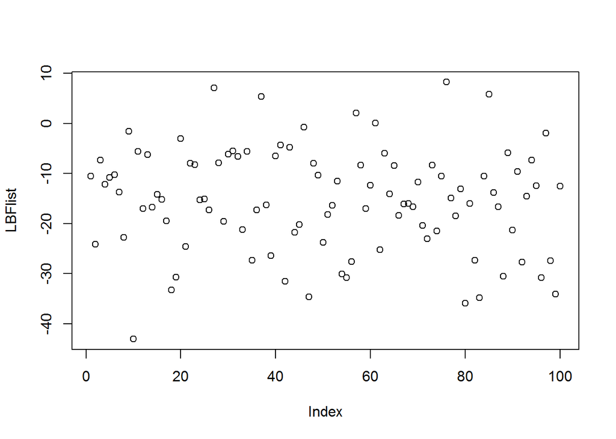

```r
#We literally loop code from earlier and store the LBFs

LBFlist <-c()
set.seed(300)
for(D in 1:100)
{
dataset <- rnorm(500)
X1 <- dataset[1:(length(dataset)*.3)]
X2 <- dataset[(length(dataset)*.3 + 1):(length(dataset)*.6)]
X3 <- dataset[(length(dataset)*.6 + 1):(length(dataset))]

GaussKernLik <- function(h,X1,X2)
{
  prod <- 0
  k <- length(X1)
  n <- length(X2)
  for(j in 1:n)
  {
    sum <- 0
    for(i in 1:k)
    {
      sum <- sum + exp(-.5*((X2[j]-X1[i])/h)^2)
    }
    prod <- prod + log(sum) + log((1/sqrt(2*pi))) + log((k*h)^(-1))
  }
  return(prod)
}
h<-1
Optimumbandwidthreg <- optimize(GaussKernLik, X1 = X1, X2 = X2, lower = .00001, upper = 5, maximum = TRUE, tol = .001)

#Optimize runs pretty fast.
X1perm <- datasetperm[1:(length(dataset)*.3)]
X2perm <- datasetperm[(length(dataset)*.3 + 1):(length(dataset)*.6)]
X3perm <- datasetperm[(length(dataset)*.6 + 1):(length(dataset))]


Optimumbandwidthperm <- optimize(GaussKernLik, X1 = X1perm, X2 = X2perm, lower = .00001, upper = 5, maximum = TRUE, tol = .001)

#We have an estimate for our bandwidth, we proceed with the test.

BFPriorFree <- GaussKernLik(Optimumbandwidthreg$maximum,X1 = X1, X2 = X3) - GaussKernLik(Optimumbandwidthperm$maximum,X1 = X1perm, X2 = X3perm)

  LBFlist[D] <- BFPriorFree
}
plot(LBFlist)
```

```r
summary(LBFlist)
```

```
##    Min. 1st Qu.  Median    Mean 3rd Qu.    Max.
## -43.059 -21.523 -14.983 -15.289  -7.960   8.268
```

Perhaps its reasonable to examine the distribution of the log(BF)?

[output not shown]